# Comparing Two Means

### Example 1: Do Women Talk More Than Men?

Researchers equiped male and female college students with a small device that secretly recorded sounds for a random 30 seconds during each 12.5 minute period over 2 days. By counting the words each subject spoke while being recorded, the researchers were able to estimate how many words each subject spoke per day.

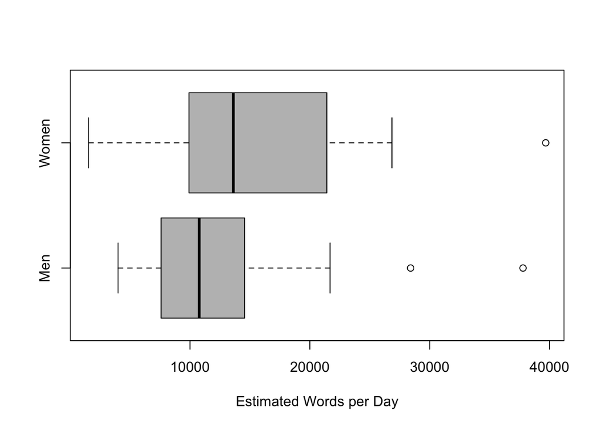

```r
talking <- read.csv("http://people.hsc.edu/faculty-staff/blins/classes/spring18/math222/examples/talking.csv")
men <- subset(talking,Sex=="M")$Words
women <- subset(talking,Sex=="F")$Words
boxplot(men,women,names = c("Men","Women"),horizontal = T,col='gray',xlab="Estimated Words per Day")
```

1. From the box and whisker plot above, it looks like there might be a difference between the average number or words spoken by male versus female college students. Use the command below to do a two-sample t-test to see if the difference is significant.

   ```r
   t.test(men, women)
   ```

2. What are the hypotheses for this hypothesis test?
3. Find a 90% confidence interval for the difference in average number of words spoken by women versus men.
4. Why can’t you use a matched pairs test with this data?

### Example 2: Marriage Ages

```r
marriages <- read.csv("http://people.hsc.edu/faculty-staff/blins/StatsExamples/marriageAges.txt")
head(marriages)
```

```
##   husb wife
## 1   25   22
## 2   25   32
## 3   51   50
## 4   25   25
## 5   38   33
## 6   30   27
```

The data frame `marriages` contains data from 24 couples that were married in Cumberland county Pennsylvania one month. Assume for now that these couples are representative of couples throughout the United States.

1. On average, who is older, the husband or the wife? What is the average age gap?
2. Make a histogram to show the distribution of the age gap. Would you say it is roughly normal?
3. Are husbands significantly older than their wives, on average? Use the `t.test()` function to find out.
4. What are the correct null and alternative hypotheses for this situation?
5. Use the formula $\displaystyle \bar{x} \pm t^* \sqrt{s^2 + \frac{s^2}{N}}$ to make a prediction interval for the age difference of 80% of all couples.